# Residual Diagnostics

Opioid overdose emergency department visit rates in Virginia counties.

Faysal Shaikh

Last updated June 17, 2024

The goal of this document is to perform residual diagnostics on our various mixed-effects models to ensure we are not violating any assumptions of this technique.

```r
library(tidyverse)
library(readxl)
library(sf)
library(broom)
library(nlme)
# library(lme4)
# library(stringr)
library(tsibble)
library(fable) # also loads fabletools
# library(feasts)
library(energy) # multivariate normal test
```

# Data loading and preprocessing (based on inclusion/exclusion criteria)

We begin by loading-in our data from our previous multi-level modeling notebook (after it had been preprocessed):

```r
# setwd('D:/Codebase/ms-thesis') # hardcoded for now, for laptop
combined_edvisits_df <- readRDS('../data/VA-county-opioid-ED-visits-2015-to-2023.RDS') %>%
    mutate(Year.adj = Year - 2015) %>% # implement global year-adjustment here
    filter(Locality != 'VIRGINIA') # to make things easier, county-only
```

Our dataset involve certain localities which are combined and replicated. This seems to be in scenarios where a zip code may be considered to belong to any of multiple localities, so the data deal with this by simply assigning it to the largest locality in the merge (and replicating those combined numbers for the constituent localities). Without removing these replicates, we are potentially oversampling those data points in our model.

The list of replicated localities is below:

```r
# recode replicates for removal
combined_edvisits_df[['Locality']] <- combined_edvisits_df[['Locality']] %>%
    recode(
        'ALLEGHANY COUNTY' = 'ALLEGHANY COUNTY AND COVINGTON CITY',
        'COVINGTON CITY' = '(REMOVE) COVINGTON CITY',
        'ALBEMARLE COUNTY' = 'ALBEMARLE COUNTY AND CHARLOTTESVILLE CITY',
        'CHARLOTTESVILLE CITY' = '(REMOVE) CHARLOTTESVILLE CITY',
        'AUGUSTA COUNTY' = 'AUGUSTA COUNTY, STAUNTON CITY, AND WAYNESBORO CITY',
        'STAUNTON CITY' = '(REMOVE) STAUNTON CITY',
        'WAYNESBORO CITY' = '(REMOVE) WAYNESBORO CITY',
        'CHESTERFIELD COUNTY' = 'CHESTERFIELD COUNTY AND COLONIAL HEIGHTS CITY',
        'COLONIAL HEIGHTS CITY' = '(REMOVE) COLONIAL HEIGHTS CITY',
        'FREDERICK COUNTY' = 'FREDERICK COUNTY AND WINCHESTER CITY',
        'WINCHESTER CITY' = '(REMOVE) WINCHESTER CITY',
        'FAIRFAX COUNTY' = 'FAIRFAX COUNTY, FAIRFAX CITY, AND FALLS CHURCH CITY',
        'FAIRFAX CITY' = '(REMOVE) FAIRFAX CITY',
        'FALLS CHURCH CITY' = '(REMOVE) FALLS CHURCH CITY',
        'GRAYSON COUNTY' = 'GRAYSON COUNTY AND GALAX CITY',
        'GALAX CITY' = '(REMOVE) GALAX CITY',
        'GREENSVILLE COUNTY' = 'GREENSVILLE COUNTY AND EMPORIA CITY',
        'EMPORIA CITY' = '(REMOVE) EMPORIA CITY',
        'HENRY COUNTY' = 'HENRY COUNTY AND MARTINSVILLE CITY',
        'MARTINSVILLE CITY' = '(REMOVE) MARTINSVILLE CITY',
        'MONTGOMERY COUNTY' = 'MONTGOMERY COUNTY AND RADFORD CITY',
        'RADFORD CITY' = '(REMOVE) RADFORD CITY',
        'PITTSYLVANIA COUNTY' = 'PITTSYLVANIA COUNTY AND DANVILLE CITY',
        'DANVILLE CITY' = '(REMOVE) DANVILLE CITY',
        'PRINCE GEORGE COUNTY' = 'PRINCE GEORGE COUNTY, HOPEWELL CITY, AND PETERSBURG CITY',
        'HOPEWELL CITY' = '(REMOVE) HOPEWELL CITY',
        'PETERSBURG CITY' = '(REMOVE) PETERSBURG CITY',
        'PRINCE WILLIAM COUNTY' = 'PRINCE WILLIAM COUNTY, MANASSAS CITY, AND MANASSAS PARK CITY',
        'MANASSAS CITY' = '(REMOVE) MANASSAS CITY',
        'MANASSAS PARK CITY' = '(REMOVE) MANASSAS PARK CITY',
        'ROANOKE COUNTY' = 'ROANOKE COUNTY, ROANOKE CITY, AND SALEM CITY',
        'ROANOKE CITY' = '(REMOVE) ROANOKE CITY',
        'SALEM CITY' = '(REMOVE) SALEM CITY',
        'ROCKINGHAM COUNTY' = 'ROCKINGHAM COUNTY AND HARRISONBURG CITY',
        'HARRISONBURG CITY' = '(REMOVE) HARRISONBURG CITY',
        'ROCKBRIDGE COUNTY' = 'ROCKBRIDGE COUNTY, BUENA VISTA CITY, AND LEXINGTON CITY',
        'BUENA VISTA CITY' = '(REMOVE) BUENA VISTA CITY',
        'LEXINGTON CITY' = '(REMOVE) LEXINGTON CITY',
        'SOUTHAMPTON COUNTY' = 'SOUTHAMPTON COUNTY AND FRANKLIN CITY',
        'FRANKLIN CITY' = '(REMOVE) FRANKLIN CITY',
        'WASHINGTON COUNTY' = 'WASHINGTON COUNTY AND BRISTOL CITY',
        'BRISTOL CITY' = '(REMOVE) BRISTOL CITY',
        'WISE COUNTY' = 'WISE COUNTY AND NORTON CITY',
        'NORTON CITY' = '(REMOVE) NORTON CITY'
    )

# remove replicates via regular expression
combined_edvisits_df <- combined_edvisits_df %>%
    filter(!grepl('\\(REMOVE\\)', Locality)) # remove localities coded for removal
```

There are some datapoints that additionally have issues with data quality for specifically the measure of our interest, opioid overdose ED visit rates per 10K ED visits. There are given below (converted into our combined localities described above):

- Appomattox
- Buchanan
- Dickenson
- Dinwiddie
- Frederick
- Gloucester
- Greensville
- Hampton
- Harrisonburg
- Henrico
- James City
- Lancaster
- Lexington
- Manassas Park
- Mathews
- Nelson
- Northumberland
- Orange
- Prince Edward
- Prince George
- Prince William
- Richmond City
- Rockbridge
- Rockingham
- Spotsylvania
- Sussex
- Winchester
- York

```r
# recode localities with data quality issues for removal
combined_edvisits_df[['Locality']] <- combined_edvisits_df[['Locality']] %>%
    recode(
        'APPOMATTOX COUNTY' = '(QUALITY) APPOMATTOX COUNTY',
        'BUCHANAN' = '(QUALITY) BUCHANAN COUNTY',
        'DICKENSON'= '(QUALITY) DICKENSON COUNTY',
        'DINWIDDIE COUNTY' = '(QUALITY) DINWIDDIE COUNTY',
        'FREDERICK COUNTY AND WINCHESTER CITY' = '(QUALITY) FREDERICK COUNTY AND WINCHESTER CITY',
        'GLOUCESTER COUNTY' = '(QUALITY) GLOUCESTER COUNTY',
        'GREENSVILLE COUNTY AND EMPORIA CITY' = '(QUALITY) GREENSVILLE COUNTY AND EMPORIA CITY',
        'HAMPTON CITY' = '(QUALITY) HAMPTON CITY',
        'HENRICO COUNTY' = '(QUALITY) HENRICO COUNTY',
        'JAMES CITY COUNTY' = '(QUALITY) JAMES CITY COUNTY',
        'LANCASTER COUNTY' = '(QUALITY) LANCASTER COUNTY',
        'MATHEWS COUNTY' = '(QUALITY) MATHEWS COUNTY',
        'NELSON COUNTY' = '(QUALITY) NELSON CITY',
        'NORTHUMBERLAND COUNTY' = '(QUALITY) NORTHUMBERLAND COUNTY',
        'ORANGE COUNTY' = '(QUALITY) ORANGE COUNTY',
        'PRINCE EDWARD COUNTY' = '(QUALITY) PRINCE EDWARD COUNTY',
        'PRINCE GEORGE COUNTY, HOPEWELL CITY, AND PETERSBURG CITY' = '(QUALITY) PRINCE GEORGE COUNTY, HOPEWELL CITY, AND PETERSBURG CITY',
        'PRINCE WILLIAM COUNTY, MANASSAS CITY, AND MANASSAS PARK CITY' = '(QUALITY) PRINCE WILLIAM COUNTY, MANASSAS CITY, AND MANASSAS PARK CITY',
        'RICHMOND CITY' = '(QUALITY) RICHMOND CITY',
        'ROCKBRIDGE COUNTY, BUENA VISTA CITY, AND LEXINGTON CITY' = '(QUALITY) ROCKBRIDGE COUNTY, BUENA VISTA CITY, AND LEXINGTON CITY',
        'ROCKHINGHAM COUNTY AND HARRISONBURG CITY' = '(QUALITY) ROCKINGHAM COUNTY AND HARRISONBURG CITY',
        'SPOTSYLVANIA COUNTY' = '(QUALITY) SPOTSYLVANIA COUNTY',
        'SUSSEX COUNTY' = '(QUALITY) SUSSEX COUNTY',
        'YORK COUNTY' = '(QUALITY) YORK COUNTY'
    )

# remove localities with data quality issues via regular expression
combined_edvisits_df <- combined_edvisits_df %>%
    filter(!grepl('\\(QUALITY\\)', Locality)) # remove localities coded for removal
```

ACCOMACK COUNTY, ALBEMARLE COUNTY AND CHARLOTTESVILLE CITY, ALEXANDRIA CITY, ALLEGHANY COUNTY AND COVINGTON CITY, AMELIA COUNTY, AMHERST COUNTY, ARLINGTON COUNTY, AUGUSTA COUNTY, STAUNTON CITY, AND WAYNESBORO CITY, BATH COUNTY, BEDFORD COUNTY, BLAND COUNTY, BOTETOURT COUNTY, BRUNSWICK COUNTY, BUCHANAN COUNTY, BUCKINGHAM COUNTY, CAMPBELL COUNTY, CAROLINE COUNTY, CARROLL COUNTY, CHARLES CITY COUNTY, CHARLOTTE COUNTY, CHESAPEAKE CITY, CHESTERFIELD COUNTY AND COLONIAL HEIGHTS CITY, CLARKE COUNTY, CRAIG COUNTY, CULPEPER COUNTY, CUMBERLAND COUNTY, DICKENSON COUNTY, ESSEX COUNTY, FAIRFAX COUNTY, FAIRFAX CITY, AND FALLS CHURCH CITY, FAUQUIER COUNTY, FLOYD COUNTY, FLUVANNA COUNTY, FRANKLIN COUNTY, FREDERICKSBURG CITY, GILES COUNTY, GOOCHLAND COUNTY, GRAYSON COUNTY AND GALAX CITY, GREENE COUNTY, HALIFAX COUNTY, HANOVER COUNTY, HENRY COUNTY AND MARTINSVILLE CITY, HIGHLAND COUNTY, ISLE OF WIGHT COUNTY, KING AND QUEEN COUNTY, KING GEORGE COUNTY, KING WILLIAM COUNTY, LEE COUNTY, LOUDOUN COUNTY, LOUISA COUNTY, LUNENBURG COUNTY, LYNCHBURG CITY, MADISON COUNTY, MECKLENBURG COUNTY, MIDDLESEX COUNTY, MONTGOMERY COUNTY AND RADFORD CITY, NEW KENT COUNTY, NEWPORT NEWS CITY, NORFOLK CITY, NORTHAMPTON COUNTY, NOTTOWAY COUNTY, PAGE COUNTY, PATRICK COUNTY, PITTSYLVANIA COUNTY AND DANVILLE CITY, POQUOSON CITY, PORTSMOUTH CITY, POWHATAN COUNTY, PULASKI COUNTY, RAPPAHANNOCK COUNTY, RICHMOND COUNTY, ROANOKE COUNTY, ROANOKE CITY, AND SALEM CITY, ROCKINGHAM COUNTY AND HARRISONBURG CITY, RUSSELL COUNTY, SCOTT COUNTY, SHENANDOAH COUNTY, SMYTH COUNTY, SOUTHAMPTON COUNTY AND FRANKLIN CITY, STAFFORD COUNTY, SUFFOLK CITY, SURRY COUNTY, TAZEWELL COUNTY, VIRGINIA BEACH CITY, WARREN COUNTY, WASHINGTON COUNTY AND BRISTOL CITY, WESTMORELAND COUNTY, WILLIAMSBURG CITY, WISE COUNTY AND NORTON CITY, WYTHE COUNTY.

# Full-dataset data exploration and model specification

To begin, we will make our work as close to prior published work as possible. Though our outcome variable is slightly different (published: average monthly opioid overdose ED visit rates per 100k population; our: average monthly opioid overdose ED visit rates per 10k ED visits, soon-to-be-replaced by an annual-aggregated opioid overdose ED visit rates per 10k ED visits), we can mimick the model specification for each of our mixed model types (in increasing sophistication/terms: unconditional growth, fixed growth, random growth, and random growth with time-varying covariates). Before this, however, we should explore our outcome variable.

### Data exploration

We begin by creating 2 facet plots, one with a fixed y-axis for all county/city localities (to show trends across county/city localities on the same scale) and one with a “free” y-axis for all county/city localities (the axis “zooms-in” to the scale of a given county/city locality’s data, to see more representatively any ups and downs).

```r
# run this by hand to generate plots as images (more readable)
combined_edvisits_df %>% # free_y version
    ggplot(mapping = aes(x = Year.adj, y = ed_visit_rate_per_100K.combined_annual)) +
    geom_line() +
    geom_smooth(method = lm, se = FALSE, fullrange = TRUE) +
    facet_wrap(~ Locality, scales = 'free_y') + # free_y allows different y-axes
    theme(strip.text.x = element_text(size = 6))


combined_edvisits_df %>% # regular, static y-axis version
    ggplot(mapping = aes(x = Year.adj, y = ed_visit_rate_per_100K.combined_annual)) +
    geom_line() +
    geom_smooth(method = lm, se = FALSE, fullrange = TRUE) +
    facet_wrap(~ Locality) +
    theme(strip.text.x = element_text(size = 6))

# TODO:
# - save files to output folder
# - implement higher-resolution (potentially SVG?) images
# - add images to document via markdown or HTML commands
```

Now that we have explored our data a little, let’s get into specifying our mixed models and looking at their residuals.

### Model specification

We provide the same types of models as before, called as such:

- Unconditional growth: intecept-only model with random intercept
- Fixed growth: intercept and time-slope model with random intercept
- Random growth: intercept and time-slope model with random intercept and slope
- Random growth with time-varying covariates: self-explanatory, though we may need to look into the validity of using time-varying covariates in a model like this (potentially looking at additional residual diagnostics).

Now that we have specified our models, let’s engage in examining residuals and performing diagnostics.

```r
model_1_unconditional_growth <- combined_edvisits_df %>%
    select(ed_visit_rate_per_100K.combined_annual, Year.adj, zHB, zCC, zSEF, zPE) %>%
    lme(
        fixed = ed_visit_rate_per_100K.combined_annual ~
            1,
        random = ~ 1 | Locality
    )
summary(model_1_unconditional_growth)
```

```
## Linear mixed-effects model fit by REML
##   Data: .
##        AIC      BIC    logLik
##   8596.378 8610.364 -4295.189
##
## Random effects:
##  Formula: ~1 | Locality
##         (Intercept) Residual
## StdDev:     55.2145 51.17113
##
## Fixed effects:  ed_visit_rate_per_100K.combined_annual ~ 1
##                Value Std.Error  DF  t-value p-value
## (Intercept) 128.1795  6.195646 696 20.68865       0
##
## Standardized Within-Group Residuals:
##        Min         Q1        Med         Q3        Max
## -3.6934104 -0.5072923 -0.0733406  0.4324956  7.0141423
##
## Number of Observations: 783
## Number of Groups: 87
```

```r
model_2_fixed_growth <- combined_edvisits_df %>%
    select(ed_visit_rate_per_100K.combined_annual, Year.adj, zHB, zCC, zSEF, zPE) %>%
    lme(
        fixed = ed_visit_rate_per_100K.combined_annual ~
            Year.adj,
        random = ~ 1 | Locality
    )
summary(model_2_fixed_growth)
```

```
## Linear mixed-effects model fit by REML
##   Data: .
##        AIC      BIC    logLik
##   8512.214 8530.857 -4252.107
##
## Random effects:
##  Formula: ~1 | Locality
##         (Intercept) Residual
## StdDev:    55.51369  48.1698
##
## Fixed effects:  ed_visit_rate_per_100K.combined_annual ~ Year.adj
##                 Value Std.Error  DF   t-value p-value
## (Intercept) 102.81862  6.745231 695 15.243157       0
## Year.adj      6.34023  0.666714 695  9.509669       0
##  Correlation:
##          (Intr)
## Year.adj -0.395
##
## Standardized Within-Group Residuals:
##         Min          Q1         Med          Q3         Max
## -3.45227253 -0.56292983 -0.03856871  0.45331052  6.86945908
##
## Number of Observations: 783
## Number of Groups: 87
```

```r
model_3_random_growth <- combined_edvisits_df %>%
    select(ed_visit_rate_per_100K.combined_annual, Year.adj, zHB, zCC, zSEF, zPE) %>%
    lme(
        fixed = ed_visit_rate_per_100K.combined_annual ~
            Year.adj,
        random = ~ Year.adj | Locality
    )
summary(model_3_random_growth)
```

```
## Linear mixed-effects model fit by REML
##   Data: .
##        AIC      BIC    logLik
##   8297.045 8325.008 -4142.522
##
## Random effects:
##  Formula: ~Year.adj | Locality
##  Structure: General positive-definite, Log-Cholesky parametrization
##             StdDev   Corr
## (Intercept) 45.91142 (Intr)
## Year.adj    11.07351 -0.218
## Residual    37.54893
##
## Fixed effects:  ed_visit_rate_per_100K.combined_annual ~ Year.adj
##                 Value Std.Error  DF   t-value p-value
## (Intercept) 102.81862  5.509131 695 18.663310       0
## Year.adj      6.34023  1.295977 695  4.892239       0
##  Correlation:
##          (Intr)
## Year.adj -0.33
##
## Standardized Within-Group Residuals:
##         Min          Q1         Med          Q3         Max
## -3.21456949 -0.50942365 -0.01683439  0.48331104  6.54997473
##
## Number of Observations: 783
## Number of Groups: 87
```

```r
model_4_random_growth_with_TVCs <- combined_edvisits_df %>%
    select(ed_visit_rate_per_100K.combined_annual, Year.adj, zHB, zCC, zSEF, zPE) %>%
    na.omit() %>% # 1 set of z-scores (all 4) is NA: 2015 HIGHLAND COUNTY
    lme(
        fixed = ed_visit_rate_per_100K.combined_annual ~
            Year.adj +
            zHB + zCC + zSEF + zPE,
        random = ~ Year.adj | Locality
    )
summary(model_4_random_growth_with_TVCs)
```

```
## Linear mixed-effects model fit by REML
##   Data: .
##        AIC      BIC    logLik
##   8255.825 8302.367 -4117.913
##
## Random effects:
##  Formula: ~Year.adj | Locality
##  Structure: General positive-definite, Log-Cholesky parametrization
##             StdDev   Corr
## (Intercept) 46.08589 (Intr)
## Year.adj    11.12109 -0.276
## Residual    37.61821
##
## Fixed effects:  ed_visit_rate_per_100K.combined_annual ~ Year.adj + zHB + zCC +      zSEF + zPE
##                 Value Std.Error  DF   t-value p-value
## (Intercept) 104.12096   5.59127 690 18.622074  0.0000
## Year.adj      6.26056   1.30440 690  4.799572  0.0000
## zHB          45.59349  26.68824 690  1.708374  0.0880
## zCC         -38.45716  39.32349 690 -0.977969  0.3284
## zSEF         -0.08491  22.24293 690 -0.003817  0.9970
## zPE         -15.72182  57.01557 690 -0.275746  0.7828
##  Correlation:
##          (Intr) Yer.dj zHB    zCC    zSEF
## Year.adj -0.367
## zHB       0.023 -0.046
## zCC      -0.118 -0.042 -0.070
## zSEF      0.096  0.045 -0.512 -0.315
## zPE       0.003  0.020 -0.021 -0.132 -0.004
##
## Standardized Within-Group Residuals:
##          Min           Q1          Med           Q3          Max
## -3.183090129 -0.516795334 -0.001604497  0.467990267  6.597055086
##
## Number of Observations: 782
## Number of Groups: 87
```

### Residual diagnostics

For oue maximally-specified model, we are interested in diagnosing residuals in accordance with the guidance found in the [Introduction to Multilevel Modeling online text](https://www.learn-mlms.com/12-module-12.html#an-aside-extracting-residuals):

- level-1 residuals (at individual data-point level) are independent of level-1 predictors, based on visual inspection of scatterplots and/or correlation coefficients
- level-1 residuals are normally distributed, based on visual inspection of quantile-quantile (qq) plots and/or Shapiro-Wilk test for normality
- level-2 residuals (at the group level, in our case, for each county/city locality) are independent of one another and of level-2 predictors, based on visual inspection of scatterplots and/or correlation coefficients
  - in our model, we do not have any level-2 predictors (these would be any per-locality covariates static across time)
- level-2 residuals are multivariate-normal

As we have described examining data and residuals together, we begin by extracting the relevant data from the overall dataset.

```r
level_1_data <- combined_edvisits_df %>%
    select(Year, Locality, Year.adj, zHB, zCC, zSEF, zPE, ed_visit_rate_per_100K.combined_annual)

level_2_data <- combined_edvisits_df %>%
    ungroup() %>% # currently grouped by year
    group_by(Locality) %>%
    mutate(local_mean_ed_visit_rate_per_100K.combined_annual = mean(ed_visit_rate_per_100K.combined_annual)) %>%
    select(Locality, local_mean_ed_visit_rate_per_100K.combined_annual) %>%
    unique() # 1 row per county/city locality
```

With our relevant data extracted at level-1 and level-2, we begin our residuals diagnostics for our maximally-specified model.

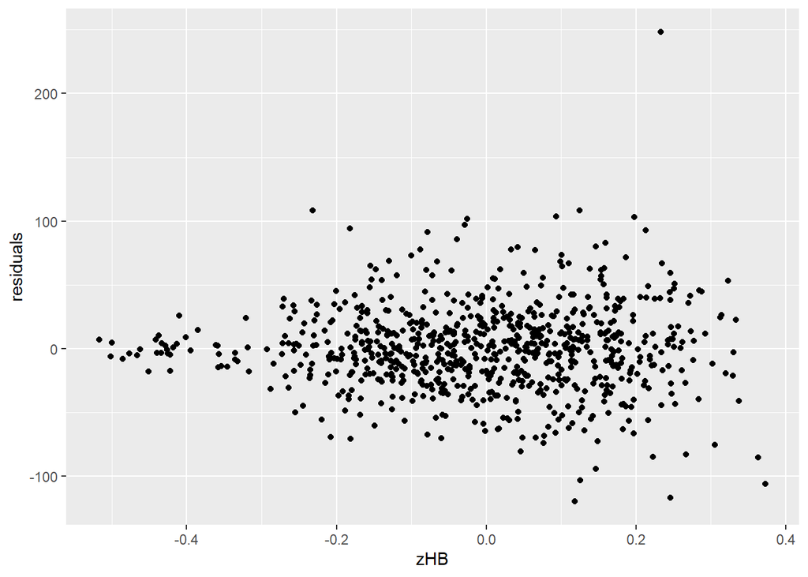

```r
# extract level-1 residuals
model_4_l1_residuals <- level_1_data %>%
    na.omit() # as we did in our model 4 creation
model_4_l1_residuals$l1_residuals <- residuals(model_4_random_growth_with_TVCs)

# extract level-2 residuals
model_4_l2_residuals <- level_2_data
model_4_l2_residuals$intercept_residual <- ranef(model_4_random_growth_with_TVCs)[, 1]
model_4_l2_residuals$timeslope_residual <- ranef(model_4_random_growth_with_TVCs)[, 2]

# test a: level-1 residuals independent of level-1 predictors
model_4_l1_residuals %>%
    ggplot(mapping = aes(x = zHB, y = l1_residuals)) +
    geom_point() +
    labs(y = "residuals")
```

```r
cor.test(model_4_l1_residuals$zHB,  model_4_l1_residuals$l1_residuals)
```

```
##
##  Pearson's product-moment correlation
##
## data:  model_4_l1_residuals$zHB and model_4_l1_residuals$l1_residuals
## t = 0.00000000000000032704, df = 780, p-value = 1
## alternative hypothesis: true correlation is not equal to 0
## 95 percent confidence interval:
##  -0.0701078  0.0701078
## sample estimates:
##                       cor
## 0.00000000000000001170994
```

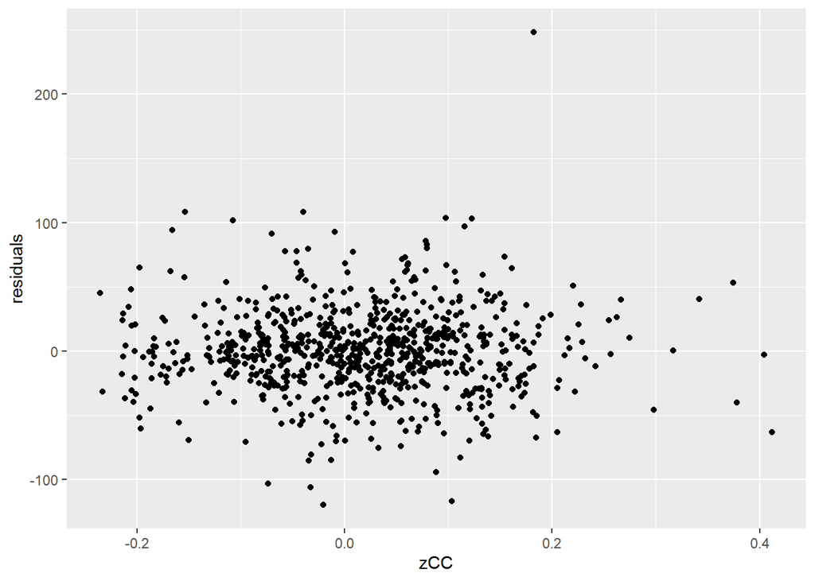

```r
model_4_l1_residuals %>%
    ggplot(mapping = aes(x = zCC, y = l1_residuals)) +
    geom_point() +
    labs(y = "residuals")
```

```r
cor.test(model_4_l1_residuals$zCC,  model_4_l1_residuals$l1_residuals)
```

```
##
##  Pearson's product-moment correlation
##
## data:  model_4_l1_residuals$zCC and model_4_l1_residuals$l1_residuals
## t = -0.0000000000000011473, df = 780, p-value = 1
## alternative hypothesis: true correlation is not equal to 0
## 95 percent confidence interval:
##  -0.0701078  0.0701078
## sample estimates:
##                        cor
## -0.00000000000000004108116
```

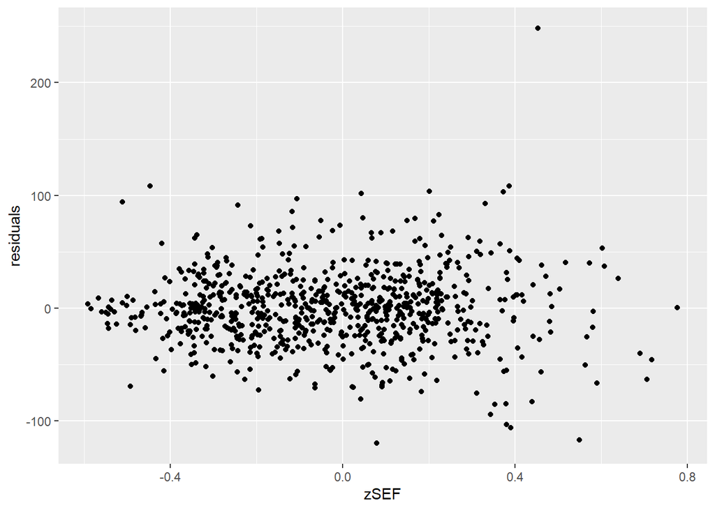

```r
model_4_l1_residuals %>%
    ggplot(mapping = aes(x = zSEF, y = l1_residuals)) +
    geom_point() +
    labs(y = "residuals")
```

```r
cor.test(model_4_l1_residuals$zSEF,  model_4_l1_residuals$l1_residuals)
```

```
##
##  Pearson's product-moment correlation
##
## data:  model_4_l1_residuals$zSEF and model_4_l1_residuals$l1_residuals
## t = -0.00000000000000060908, df = 780, p-value = 1
## alternative hypothesis: true correlation is not equal to 0
## 95 percent confidence interval:
##  -0.0701078  0.0701078
## sample estimates:
##                        cor
## -0.00000000000000002180856
```

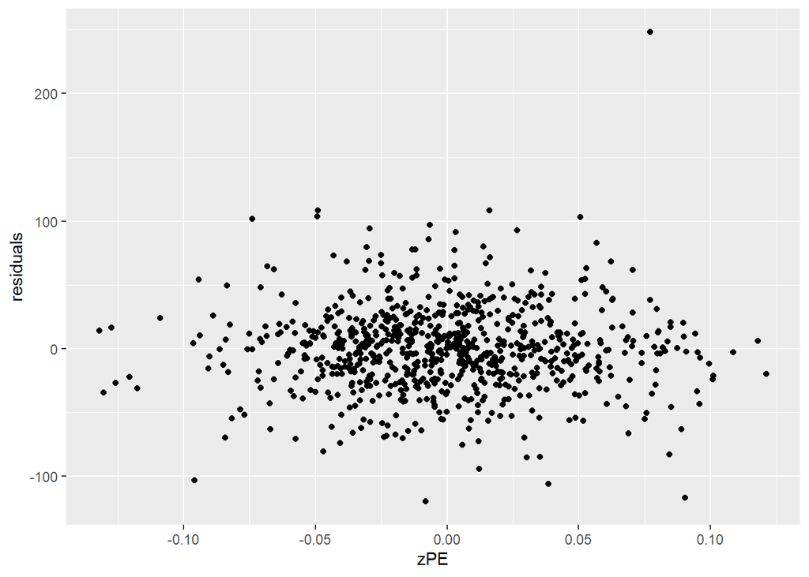

```r
model_4_l1_residuals %>%
    ggplot(mapping = aes(x = zPE, y = l1_residuals)) +
    geom_point() +
    labs(y = "residuals")
```

```r
cor.test(model_4_l1_residuals$zPE,  model_4_l1_residuals$l1_residuals)
```

```
##
##  Pearson's product-moment correlation
##
## data:  model_4_l1_residuals$zPE and model_4_l1_residuals$l1_residuals
## t = 0.000000000000000094727, df = 780, p-value = 1
## alternative hypothesis: true correlation is not equal to 0
## 95 percent confidence interval:
##  -0.0701078  0.0701078
## sample estimates:
##                        cor
## 0.000000000000000003391766
```

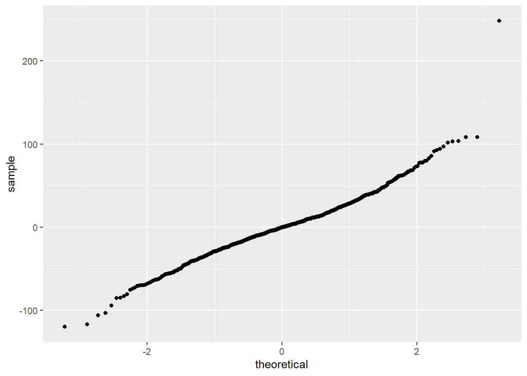

```r
# test b: level-1 residuals are normally distributed
model_4_l1_residuals %>%
    ggplot(mapping = aes(sample = l1_residuals)) +
    stat_qq()
```

```r
shapiro.test(model_4_l1_residuals$l1_residuals)
```

```
##
##  Shapiro-Wilk normality test
##
## data:  model_4_l1_residuals$l1_residuals
## W = 0.96572, p-value = 0.000000000001418
```

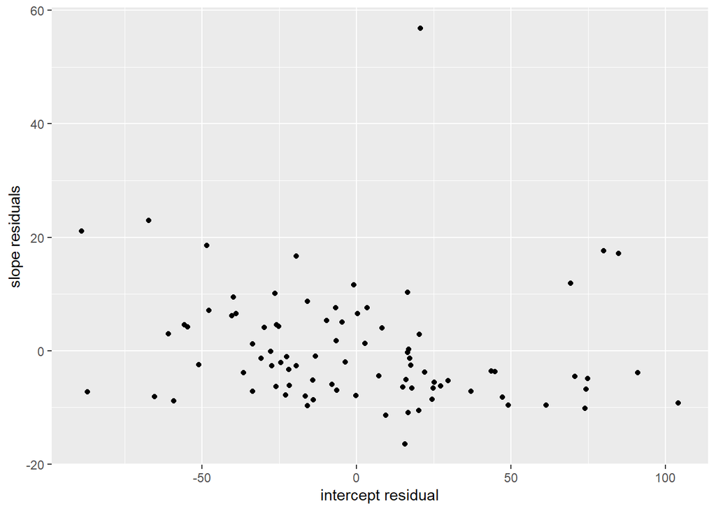

```r
# test c: level-2 residuals are independent of one another and of level-2 predictors
model_4_l2_residuals %>%
    ggplot(mapping = aes(x = intercept_residual, y = timeslope_residual)) +
    geom_point() +
    labs(x = "intercept residual", y = "slope residuals")
```

```r
cor.test(model_4_l2_residuals$intercept_residual,  model_4_l2_residuals$timeslope_residual)
```

```
##
##  Pearson's product-moment correlation
##
## data:  model_4_l2_residuals$intercept_residual and model_4_l2_residuals$timeslope_residual
## t = -1.5834, df = 85, p-value = 0.117
## alternative hypothesis: true correlation is not equal to 0
## 95 percent confidence interval:
##  -0.36683784  0.04290853
## sample estimates:
##        cor
## -0.1692697
```

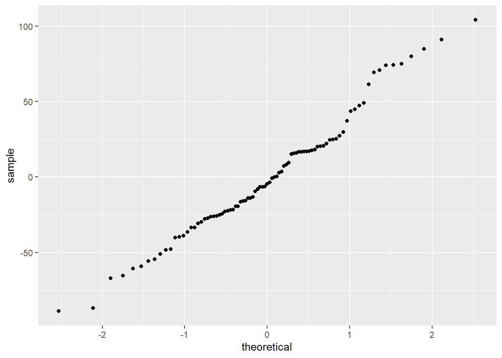

```r
# test d: level-2 residuals are multivariate-normal
model_4_l2_residuals %>%
    ggplot(aes(sample = intercept_residual)) +
    stat_qq()
```

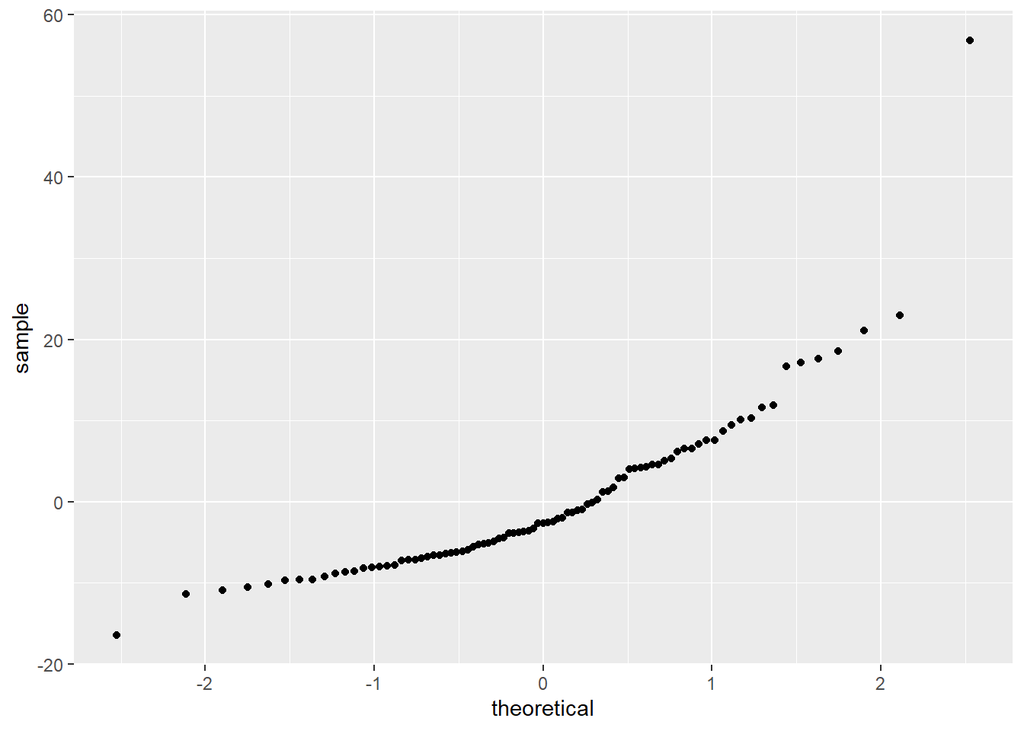

```r
model_4_l2_residuals %>%
    ggplot(aes(sample = timeslope_residual)) +
    stat_qq()
```

```r
energy::mvnorm.test(cbind(model_4_l2_residuals$intercept_residual, model_4_l2_residuals$timeslope_residual), R = 1000)
```

```
##
##  Energy test of multivariate normality: estimated parameters
##
## data:  x, sample size 87, dimension 2, replicates 1000
## E-statistic = 2.573, p-value < 0.00000000000000022
```

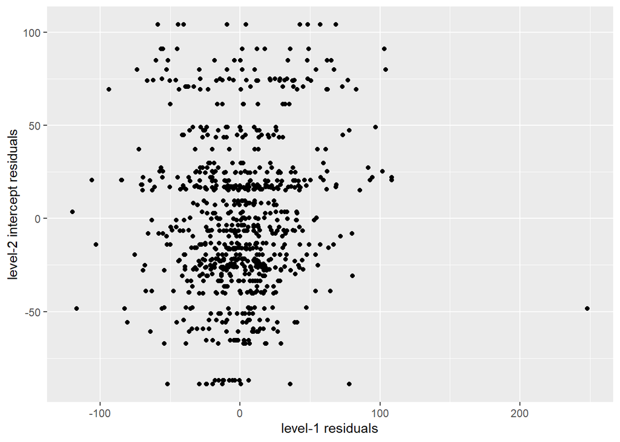

```r
# test e: level-1 and level-2 residuals are independent of one another
# # combine residuals
model_4_combined_residuals <- left_join(model_4_l1_residuals, model_4_l2_residuals, by = "Locality")
# # test they are independent
model_4_combined_residuals %>%
    ggplot(mapping = aes(x = l1_residuals, y = intercept_residual)) +
    geom_point() +
    labs(x = "level-1 residuals", y = "level-2 intercept residuals")
```

```r
cor.test(model_4_combined_residuals$l1_residuals,  model_4_combined_residuals$intercept_residual)
```

```
##
##  Pearson's product-moment correlation
##
## data:  model_4_combined_residuals$l1_residuals and model_4_combined_residuals$intercept_residual
## t = 2.5919, df = 780, p-value = 0.009724
## alternative hypothesis: true correlation is not equal to 0
## 95 percent confidence interval:
##  0.02244455 0.16146867
## sample estimates:
##        cor
## 0.09240694
```

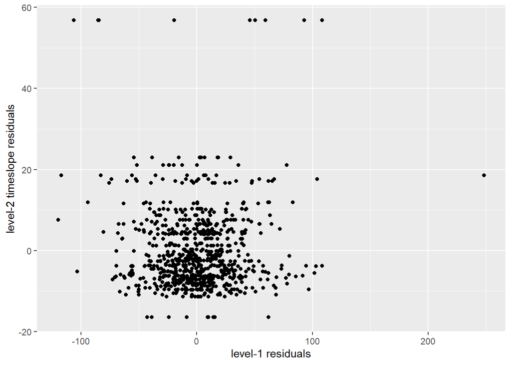

```r
model_4_combined_residuals %>%
    ggplot(mapping = aes(x = l1_residuals, y = timeslope_residual)) +
    geom_point() +
    labs(x = "level-1 residuals", y = "level-2 timeslope residuals")
```

```r
cor.test(model_4_combined_residuals$l1_residuals,  model_4_combined_residuals$timeslope_residual)
```

```
##
##  Pearson's product-moment correlation
##
## data:  model_4_combined_residuals$l1_residuals and model_4_combined_residuals$timeslope_residual
## t = 0.31323, df = 780, p-value = 0.7542
## alternative hypothesis: true correlation is not equal to 0
## 95 percent confidence interval:
##  -0.05893932  0.08125872
## sample estimates:
##        cor
## 0.01121481
```

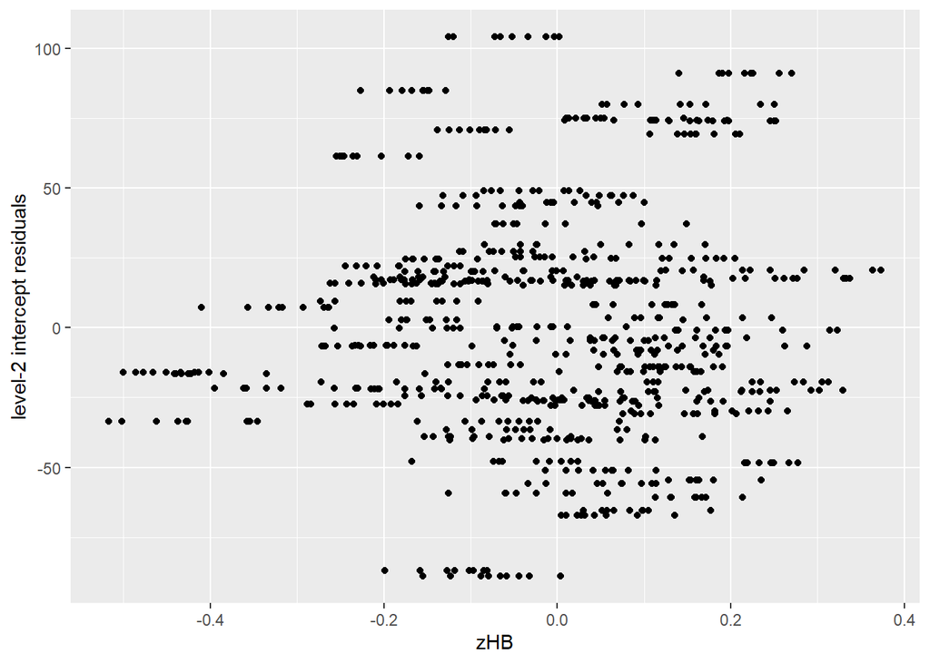

```r
# test f: predictors at any given level are not related to errors at another level
# # test f.i: level-1 residuals are independent of level-2 predictors
# # test they are independent
model_4_combined_residuals %>%
    ggplot(mapping = aes(x = zHB, y = intercept_residual)) +
    geom_point() +
    labs(y = "level-2 intercept residuals")
```

```r
cor.test(model_4_combined_residuals$zHB,  model_4_combined_residuals$intercept_residual)
```

```
##
##  Pearson's product-moment correlation
##
## data:  model_4_combined_residuals$zHB and model_4_combined_residuals$intercept_residual
## t = 0.60613, df = 780, p-value = 0.5446
## alternative hypothesis: true correlation is not equal to 0
## 95 percent confidence interval:
##  -0.04848366  0.09166624
## sample estimates:
##        cor
## 0.02169789
```

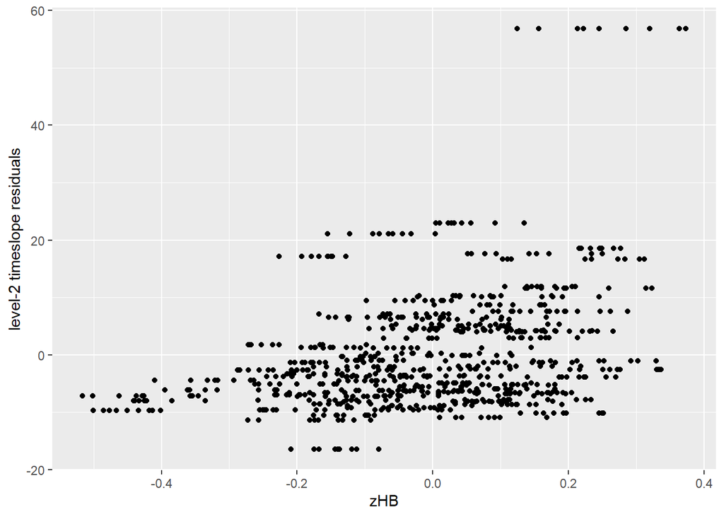

```r
model_4_combined_residuals %>%
    ggplot(mapping = aes(x = zHB, y = timeslope_residual)) +
    geom_point() +
    labs(y = "level-2 timeslope residuals")
```

```r
cor.test(model_4_combined_residuals$zHB,  model_4_combined_residuals$timeslope_residual)
```

```
##
##  Pearson's product-moment correlation
##
## data:  model_4_combined_residuals$zHB and model_4_combined_residuals$timeslope_residual
## t = 11.091, df = 780, p-value < 0.00000000000000022
## alternative hypothesis: true correlation is not equal to 0
## 95 percent confidence interval:
##  0.3069257 0.4281211
## sample estimates:
##       cor
## 0.3690914
```

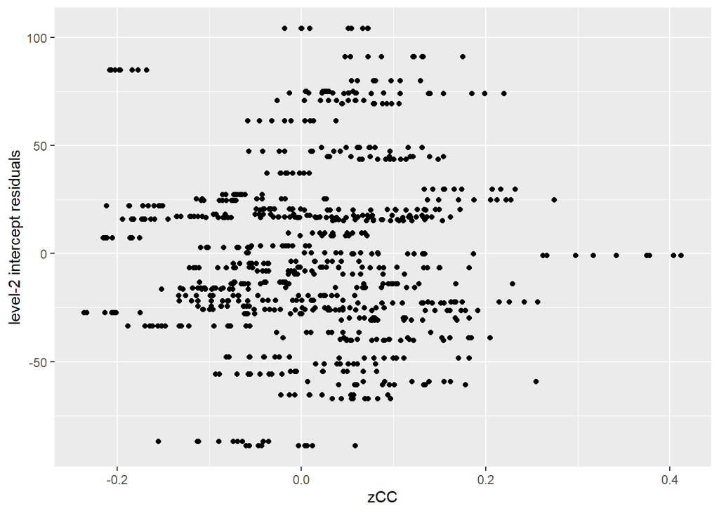

```r
model_4_combined_residuals %>%
    ggplot(mapping = aes(x = zCC, y = intercept_residual)) +
    geom_point() +
    labs(y = "level-2 intercept residuals")
```

```r
cor.test(model_4_combined_residuals$zCC,  model_4_combined_residuals$intercept_residual)
```

```
##
##  Pearson's product-moment correlation
##
## data:  model_4_combined_residuals$zCC and model_4_combined_residuals$intercept_residual
## t = 1.3579, df = 780, p-value = 0.1749
## alternative hypothesis: true correlation is not equal to 0
## 95 percent confidence interval:
##  -0.02161824  0.11826829
## sample estimates:
##        cor
## 0.04856316
```

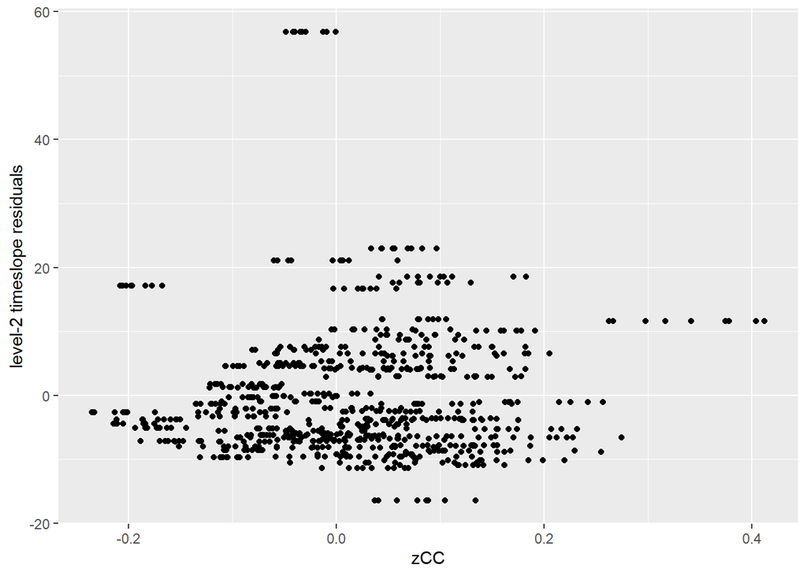

```r
model_4_combined_residuals %>%
    ggplot(mapping = aes(x = zCC, y = timeslope_residual)) +
    geom_point() +
    labs(y = "level-2 timeslope residuals")
```

```r
cor.test(model_4_combined_residuals$zCC,  model_4_combined_residuals$timeslope_residual)
```

```
##
##  Pearson's product-moment correlation
##
## data:  model_4_combined_residuals$zCC and model_4_combined_residuals$timeslope_residual
## t = 1.3553, df = 780, p-value = 0.1757
## alternative hypothesis: true correlation is not equal to 0
## 95 percent confidence interval:
##  -0.02171009  0.11817768
## sample estimates:
##        cor
## 0.04847148
```

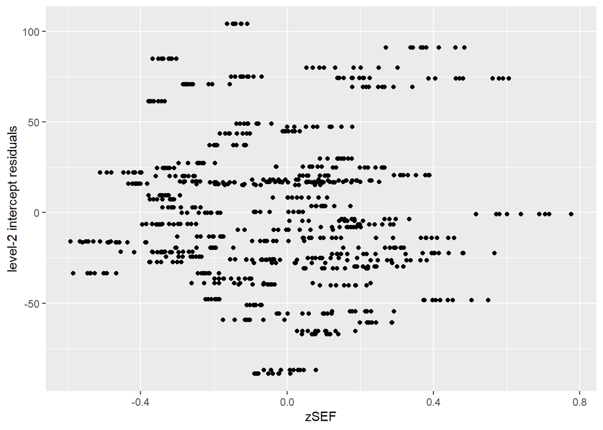

```r
model_4_combined_residuals %>%
    ggplot(mapping = aes(x = zSEF, y = intercept_residual)) +
    geom_point() +
    labs(y = "level-2 intercept residuals")
```

```r
cor.test(model_4_combined_residuals$zSEF,  model_4_combined_residuals$intercept_residual)
```

```
##
##  Pearson's product-moment correlation
##
## data:  model_4_combined_residuals$zSEF and model_4_combined_residuals$intercept_residual
## t = -0.49167, df = 780, p-value = 0.6231
## alternative hypothesis: true correlation is not equal to 0
## 95 percent confidence interval:
##  -0.08760152  0.05257084
## sample estimates:
##         cor
## -0.01760183
```

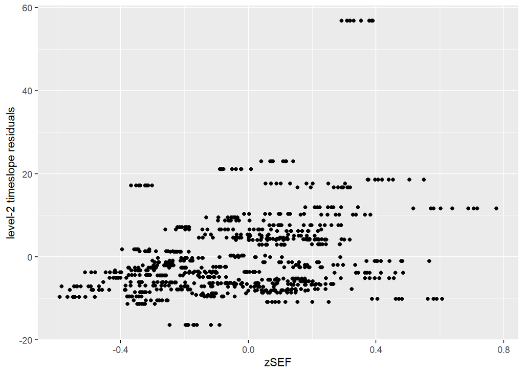

```r
model_4_combined_residuals %>%
    ggplot(mapping = aes(x = zSEF, y = timeslope_residual)) +
    geom_point() +
    labs(y = "level-2 timeslope residuals")
```

```r
cor.test(model_4_combined_residuals$zSEF,  model_4_combined_residuals$timeslope_residual)
```

```
##
##  Pearson's product-moment correlation
##
## data:  model_4_combined_residuals$zSEF and model_4_combined_residuals$timeslope_residual
## t = 10.728, df = 780, p-value < 0.00000000000000022
## alternative hypothesis: true correlation is not equal to 0
## 95 percent confidence interval:
##  0.2959010 0.4181659
## sample estimates:
##       cor
## 0.3585702
```

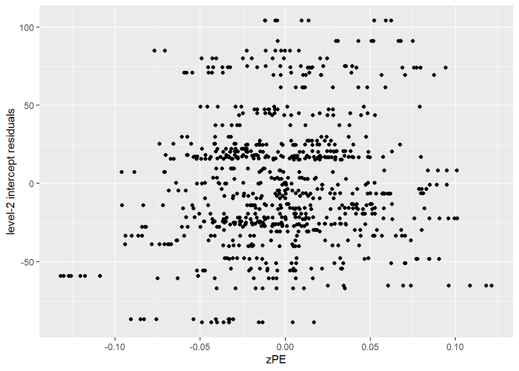

```r
model_4_combined_residuals %>%
    ggplot(mapping = aes(x = zPE, y = intercept_residual)) +
    geom_point() +
    labs(y = "level-2 intercept residuals")
```

```r
cor.test(model_4_combined_residuals$zPE,  model_4_combined_residuals$intercept_residual)
```

```
##
##  Pearson's product-moment correlation
##
## data:  model_4_combined_residuals$zPE and model_4_combined_residuals$intercept_residual
## t = 3.2107, df = 780, p-value = 0.001379
## alternative hypothesis: true correlation is not equal to 0
## 95 percent confidence interval:
##  0.04445632 0.18285188
## sample estimates:
##       cor
## 0.1142082
```

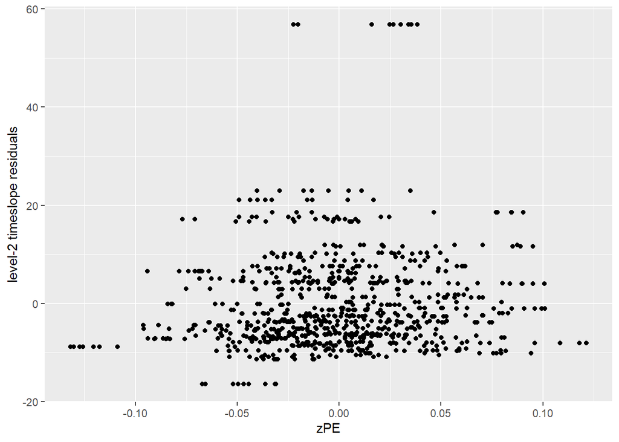

```r
model_4_combined_residuals %>%
    ggplot(mapping = aes(x = zPE, y = timeslope_residual)) +
    geom_point() +
    labs(y = "level-2 timeslope residuals")
```

```r
cor.test(model_4_combined_residuals$zPE,  model_4_combined_residuals$timeslope_residual)
```

```
##
##  Pearson's product-moment correlation
##
## data:  model_4_combined_residuals$zPE and model_4_combined_residuals$timeslope_residual
## t = 2.5473, df = 780, p-value = 0.01105
## alternative hypothesis: true correlation is not equal to 0
## 95 percent confidence interval:
##  0.02085433 0.15991878
## sample estimates:
##        cor
## 0.09082932
```

```r
# # test f.ii: level-2 residuals are independent of level-1 predictors
# # our model does not have any level-2 predictors, so we omit this test
```

# List of things that need to get done before thesis meeting

- remove replicated localities from data
- perform residual diagnostics for each of the published models, using all data
- perform residual diagnostics for the main model, using all data
- perform residual diagnostics for 1 model type, using data from 2015 to 2021 to predict 2022
- perform residual diagnostic for same model as above, using data from 2015 to 2022 to predict 2023, and show forecast performance
- perform residual diagnostic for the same model as above, using data from 2015 to 2021 to predict both 2022 and 2023, and show forecast performance